# Alex Mwai

Nuclear Physicist • Developer • Lover of all things data

## Movie Recommendation Engine

## Recommender Systems

Recommender systems, also known as recommendation engines, provide for a more personalized web experience, be it on social media, shopping websites, or content providers such as Pandora and Netflix. There are two main types of recommender systems. There are those that employ content-based filtering and those that involve collaborative filtering. Content-based filters provide recommendations based on item characteristics. An example is where a recommendation for an item is made based on similar items that a user has utilized before. On the other hand, Collaborative Filtering (CF) involves providing recommendations based on how users have responded to an item. Collabrative filtering can be further broken down to memory-based collaborative filtering and model-based collaborative filtering. As the name suggests, memory-based collaborative filtering involves building a model from the full dataset. The method algorithms utilize similarity metrics such as Euclidean distance, Pearson correlation, and cosine similarity to calculate user-item matches. In contrast, model-based collaborative filtering employs algorithms that extract information from the dataset that is then used to build a model to predict a user's rating for an item. In general, model-based CF tends to be less resource intense and better performing than memory-based CF algorithms, albeit harder to implement. In this analysis, I will be exploring the use of model-based CF to build a movie-recommendation engine based on the 100k movie ratings MovieLens dataset.

## Model-based collaborative filtering

The model-based CF algorithm used in this analysis involves matrix factorization of the user-item matrix. The idea is to characterize the original matrix as the product of two low-rank matrices, and use these to discover latent features that influence the user-item interaction. When trying to find latent features, an assumption is made that the number of latent features is smaller than the number of users, as well as the number of items. This makes intituitive sense since it is the commonality of features between users that allows us to be able to recommend items to one user based on the ratings of another.

### Matrix factorization

If **R** is the *M x N* user-item matrix, we can approximate **R** as the product of two low-rank feature matrices. **P** (*M X K*) is the factor matrix for users and **Q** (*N x K*) is the factor matrix for items (movies, in this case). *K* is the number of latent features

The cost function can be expressed as the sum of squared errors

$$\mathbf{ J = \sum_{(u, i) \in K}(R_{u, i} - \hat{R_{u, i} })^{2} } \qquad \text{(2)} $$

To avoid overfitting, we can introduce a regularization term to the cost function. $\lambda$ is the regularization parameter

$$\mathbf{ J = \sum_{(u, i) \in K}(R_{u, i} - \hat{R_{u, i} })^{2} + \lambda(||P_{u}||^{2} + ||Q_{i}||^{2})} \qquad \text{(3)} $$

The goal then is to minimize on the cost function. To do this, we take partial derivatives with respect to $\mathbf{P}$ and $\mathbf{Q}$ and set both derivatives to zero. Since we have two unknowns, $\mathbf{P}$ and $\mathbf{Q}$, we will use the Alternating Least Squares (ALS) technique to get the estimates for $\mathbf{P}$ and $\mathbf{Q}$. In this technique, we fix $\mathbf{Q}$ to get an estimate for $\mathbf{P}$ and then fix $\mathbf{P}$ to get an estimate for $\mathbf{Q}$. This is done for several iterations until there is little to no change to the Root Mean Square Error (RMSE), which is what we will use to evaluate for convergence.

The cost functions to minimize for each unknown are given by:

$$\mathbf{ J(p_{u}) = (r_{u} - p_{u}Q)W_{u}(r_{u} - p_{u}Q)^{T} + \lambda p_{u}p_{u}^{T} } \qquad \text{(4)} $$

$$\mathbf{ J(q_{i}) = (r_{i} - Pq_{i})W_{i}(r_{i} - Pq_{i})^{T} + \lambda q_{i}q_{i}^{T} } \qquad \text{(5)} $$

$ \mathbf{W_{u} } \in \mathbb{R} ^{M \times M}$ and $ \mathbf{W_{i} } \in \mathbb{R} ^{N \times N}$ are weights that we use to penalize those items that are not rated so that the model depends wholly on the rated items. $\mathbf{W}$ is defined as:

$$ \mathbf{W_{ui} } = \begin{cases} 0 & \text{if }r_{ui}=0\\ 1 & \text{else}\\ \end{cases}$$

and the update rules for the two unknowns are given as:

$$\mathbf{ p_{u} = A_{u}^{-1}V_{u} \qquad \text{where } A_{u} = QW_{u}Q^{T} + \lambda n_{u}E \text{;} \quad V_{u}=QW_{u}r_{u} } \qquad \text{(6)} $$

$$\mathbf{ q_{i} = A_{i}^{-1}V_{i} \qquad \text{where } A_{i} = P^{T}W_{i}P + \lambda n_{i}E \text{;}\quad V_{i}=P^{T}W_{i}r_{i} } \qquad \text{(7)} $$

$\mathbf{n_{u} }$ is a count of how many items each user rated while $\mathbf{n_{i} }$ is a count of how many users rated each item. $ \mathbf{E} \in \mathbb{R} ^{K \times K}$ is an identity matrix

Equations 6 and 7 are of the general form $\mathbf{ x=A^{-1}V }$ where $\mathbf{A}$ is a matrix and $\mathbf{V}$ is a vector. This equation can be solved by doing an LU decomposition of the matrix $\mathbf{A}$ followed by forward and backward substitution so as to solve for $\mathbf{x}$

To evalute the algorithm, we calculate the Root Mean Square Error (RMSE) where **N** is the total number of user-item pairs

$$ \mathbf{ RMSE = \sqrt{ { {1}\over {N} } \sum_{i=1}^{N}(R_{i} - \hat{R_{i} })^{2} } } \qquad \text{(8)} $$

## Data

The data used in this analysis is the 100K ratings MovieLens data that can be found here http://files.grouplens.org/datasets/movielens/ml-100k.zip

### Summary of data

- 100,000 ratings
- 1682 movies rated
- 943 unique users with each user rating at least 20 movies

```python
import numpy as np
import pandas as pd
import scipy.sparse as sparse
import itertools

#For prediction evaluation
from sklearn.metrics import mean_squared_error
from math import sqrt
```

```python
#Get user-movie data
header = ['user_id', 'movie_id', 'rating', 'timestamp']
df = pd.read_csv('/home/concinte/Code/RecommendationEngine/MovieLens/Data/ml-100k/u.data', sep='\t', names=header)
```

```python
df.head()
```

|  | user_id | movie_id | rating | timestamp |
| --- | --- | --- | --- | --- |
| 0 | 196 | 242 | 3 | 881250949 |
| 1 | 186 | 302 | 3 | 891717742 |
| 2 | 22 | 377 | 1 | 878887116 |
| 3 | 244 | 51 | 2 | 880606923 |
| 4 | 166 | 346 | 1 | 886397596 |

```python
#Remove unnecessary columns
df.drop(['timestamp'],inplace=True,axis=1)
df.head()
```

|  | user_id | movie_id | rating |
| --- | --- | --- | --- |
| 0 | 196 | 242 | 3 |
| 1 | 186 | 302 | 3 |
| 2 | 22 | 377 | 1 |
| 3 | 244 | 51 | 2 |
| 4 | 166 | 346 | 1 |

```python
#Get movie data
df_movie = pd.read_csv('/home/concinte/Code/RecommendationEngine/MovieLens/Data/ml-100k/u.item', sep='|',
                       usecols=[0,1],names=['movie_id','movie_title'])
```

```python
df_movie.head()
```

|  | movie_id | movie_title |
| --- | --- | --- |
| 0 | 1 | Toy Story (1995) |
| 1 | 2 | GoldenEye (1995) |
| 2 | 3 | Four Rooms (1995) |
| 3 | 4 | Get Shorty (1995) |
| 4 | 5 | Copycat (1995) |

```python
#Get the total number of users as well as number of movies
num_users = df.user_id.max()
num_movies = df.movie_id.max()
num_users, num_movies
```

```
(943, 1682)
```

```python
#Obtain the training and test datasets using cross-validation
from sklearn import cross_validation as cv
train_data, test_data = cv.train_test_split(df, test_size=0.25)
```

```python
#Create a training and test matrix
#train_matrix = sparse.dok_matrix((num_users, num_movies), dtype=float)
train_matrix = np.zeros((num_users, num_movies))
for line in train_data.itertuples():
    user = line[1]
    movie = line[2]
    rating = line[3]
    if user > num_users:
        continue
    if movie > num_movies:
        continue
    if rating != 0:
        train_matrix[user-1, movie-1] = rating

#test_matrix = sparse.dok_matrix((num_users, num_movies), dtype=float)
test_matrix = np.zeros((num_users, num_movies))
for line in test_data.itertuples():
    user = line[1]
    movie = line[2]
    rating = line[3]
    if user > num_users:
        continue
    if movie > num_movies:
        continue
    if rating != 0:
        test_matrix[user-1, movie-1] = rating
```

```python
#Initialize the various variables
#K are the latent features, lmbda is the regularlization
#parameter lambda and "iterations" denotes the number of iterations
#to perform to convergence
R = train_matrix
T = test_matrix

M, N = R.shape
K = 3
lmbda = 0.1
iterations = 50
P = 5*np.random.rand(M, K)
Q = 5*np.random.rand(N, K)
```

```python
#This function calculates the RMSE. A penalty is imposed where we have an estimated rating
#but no actual rating in R. The penalty is imposed by multiplying by W
def calcRMSE(R, P, Q, W):
    rmse = np.sqrt(np.sum(pow((W*(R - np.dot(P, Q.T))), 2))/len(R[R>0]))
    return rmse
```

To obtain the update rules, we take the derivatives of P and Q, and alternately update each factor as we fix the other. This is known as **Alternate Least Squares**. To avoid overfitting, a regularization term is introduced to the square error where lambda is the regularization parameter.

```python
#Establish update rules
def updateRules(R, T, P, Q, K):

    #Get the training weight matrix which will contain a 1 if a movie was rated and 0 if not
    W = R.copy()
    W[R > 0] = 1
    W[R == 0] = 0

    #Get the test weight matrix
    Z = T.copy()
    Z[T > 0] = 1
    Z[T == 0] = 0

    errors_T = [] #To store training RMSE
    errors_TT = [] #To store test RMSE
    E = np.eye(K) # This is a K x K identity matrix

    for i in xrange(iterations):

        #Update for P with fixed Q
        for u, Wu in enumerate(W): #Wu corresponds to the ratings by each user
            num_mov = np.count_nonzero(Wu) #Count of how many movies each user rated
            if num_mov == 0:
                num_mov = 1 # This is to guard against zero counts which would make the matrices to be singular
            #The least squares solution
            #Note that np.diag(Wu) takes the binary representation of each user (1, 0 if rated or not rated)
            #and converts into a diagonal array
            matrix = np.dot(Q.T, np.dot(np.diag(Wu), Q)) + lmbda*num_mov*E
            vector = np.dot(Q.T, np.dot(np.diag(Wu), R[u].T))
            #Factorize the matrix using LU decomposition, and then solve for P using
            #forward and backward substitution
            P[u,:] = np.linalg.solve(matrix, vector)

        #Update for Q with fixed P. Steps are duplicated
        for v, Wv in enumerate(W.T):
            num_users = np.count_nonzero(Wv) #Count of number of users that rated movie v
            if num_users == 0:
                num_users = 1
            matrix = np.dot(P.T, (np.dot(np.diag(Wv), P))) + lmbda*num_users*E
            vector = np.dot(P.T, np.dot(np.diag(Wv), R[:,v]))
            Q[v,:] = np.linalg.solve(matrix, vector)

        #Calculate RMSE for both the training and the test data
        #note that we use the P and Q trained on the training data
        #to test for generalization using the test data
        errors_T.append(calcRMSE(R, P, Q, W))
        errors_TT.append(calcRMSE(T, P, Q, Z))

    return P, Q, errors_T, errors_TT
```

```python
#Obtain the training and test errors
P_pr, Q_pr, training_err, test_err = updateRules(R, T, P, Q, K)
```

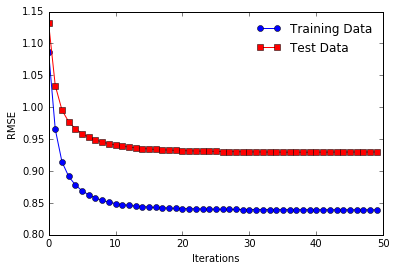

```python
#Plot the RMSE for both the train and test data as a function of iterations
import matplotlib.pyplot as plt
%matplotlib inline

plt.plot(range(iterations), training_err, marker='o', color="blue", label='Training Data');
plt.plot(range(iterations), test_err, marker='s', color="red", label='Test Data');
plt.legend(loc='upper right', frameon=False)
plt.xlabel('Iterations')
plt.ylabel('RMSE')
plt.show()
```

```python
"Final training RMSE is " + str(training_err[-1]) + " and " + "Final test RMSE is " + str(test_err[-1])
```

```
'Final training RMSE is 0.839043163076 and Final test RMSE is 0.929833014704'
```

```python
#Get the test data RMSE as a percentage of the trainig data error for
#different parameter configurations
"Percent difference between the training RMSE and test RMSE = " + str(((test_err[-1] - training_err[-1])/training_err[-1])*100)
```

```
'Percent difference between the training RMSE and test RMSE = 10.8206413715'
```

```python
### Here are some values from running different parameter configurations
```

11.58 % with K = 3; test_err = 0.936; training_err = 0.839; lambda = 0.1; iterations = 20